# PA1_template.Rmd

Aesha

11/12/2020

##Loading and preprocessing the data

```r
data <-read.csv("activity.csv")
names(data)
```

```
## [1] "steps"    "date"     "interval"
```

```r
data2 <-read.csv("activity.csv")
```

##1. What is mean total number of steps taken per day?

1.Calculate the total number of steps taken per day

```r
total_steps <- aggregate(steps~date, data, FUN=sum, na.rm=TRUE)
```

2.Make a histogram of the total number of steps taken each day

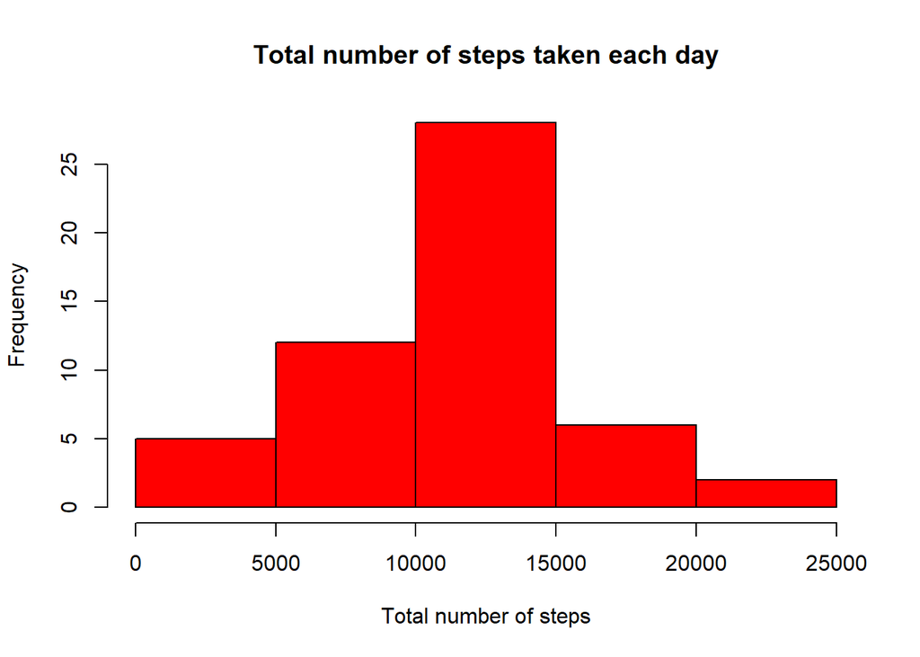

```r
hist(total_steps$steps,
     main= "Total number of steps taken each day",
     xlab="Total number of steps",
     col= "red")
```

3. Calculate and report the mean and median of the total number of steps taken per day

```r
mean_steps <- mean(total_steps$steps)
print(mean_steps)
```

```
## [1] 10766.19
```

```r
median_steps <- median(total_steps$steps)
print(median_steps)
```

```
## [1] 10765
```

##What is the average daily activity pattern? creating a dataframe with the mean of each 5-minute interval and use the funtion plot() to make the time series plot

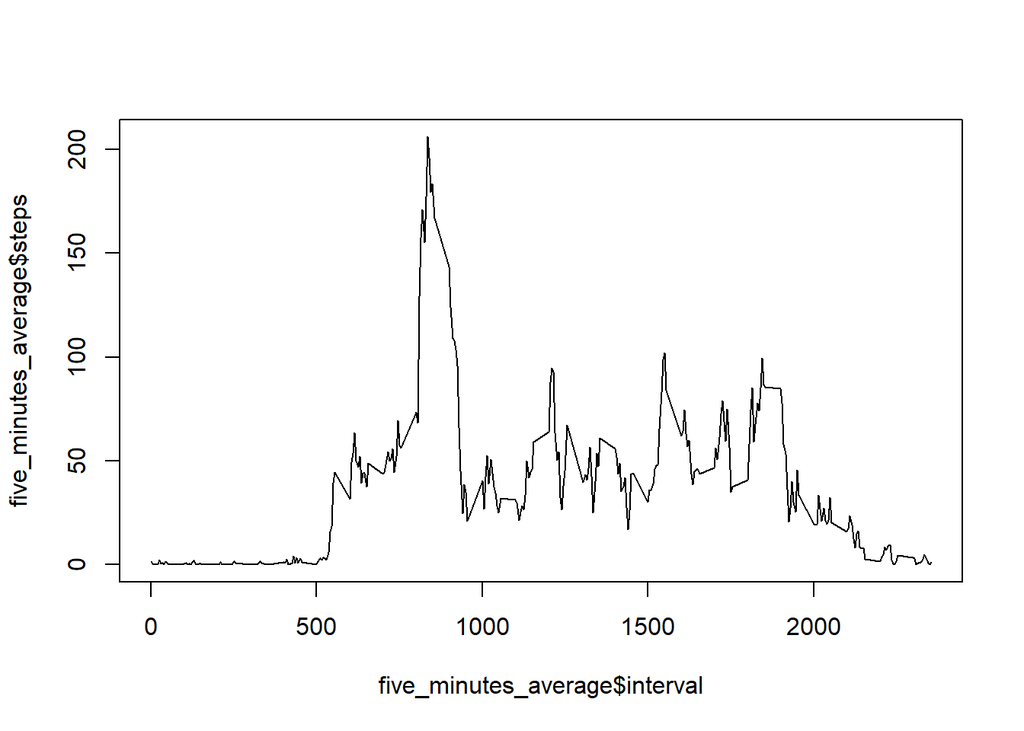

```r
five_minutes_average <- aggregate(steps~interval, data, FUN=mean, na.rm=TRUE)
plot(x = five_minutes_average$interval, y = five_minutes_average$steps, type = "l")
```

## there are a number of days/intervals where there are missing values (coded as NA). The presence of missing days may introduce bias into some calculations or summaries of the data.

Calculate and report the total number of missing values in the dataset (i.e. the total number of rows withNAs)

```r
NA_count <- sum(is.na(data$steps))
print (NA_count)
```

```
## [1] 2304
```

##Devise a strategy for filling in all of the missing values in the dataset. Find the NA positions

```r
na_pos <- which(is.na(data$steps))
```

Create a vector of means

```r
mean_vec <- rep(mean(data$steps, na.rm=TRUE), times=length(na_pos))
```

##Create a new dataset that is equal to the original dataset but with the missing data filled in. Replace the NAs by the means

```r
data[na_pos, "steps"] <- mean_vec
head(data)
```

|  | steps | date | interval |
| --- | --- | --- | --- |
| 1 | 37.3826 | 2012-10-01 | 0 |
| 2 | 37.3826 | 2012-10-01 | 5 |
| 3 | 37.3826 | 2012-10-01 | 10 |
| 4 | 37.3826 | 2012-10-01 | 15 |
| 5 | 37.3826 | 2012-10-01 | 20 |
| 6 | 37.3826 | 2012-10-01 | 25 |

```r
sum_data <- aggregate(data$steps, by=list(data$date), FUN=sum)
```

Rename the attributes

```r
names(sum_data) <- c("date", "total")
```

Compute the histogram of the total number of steps each day

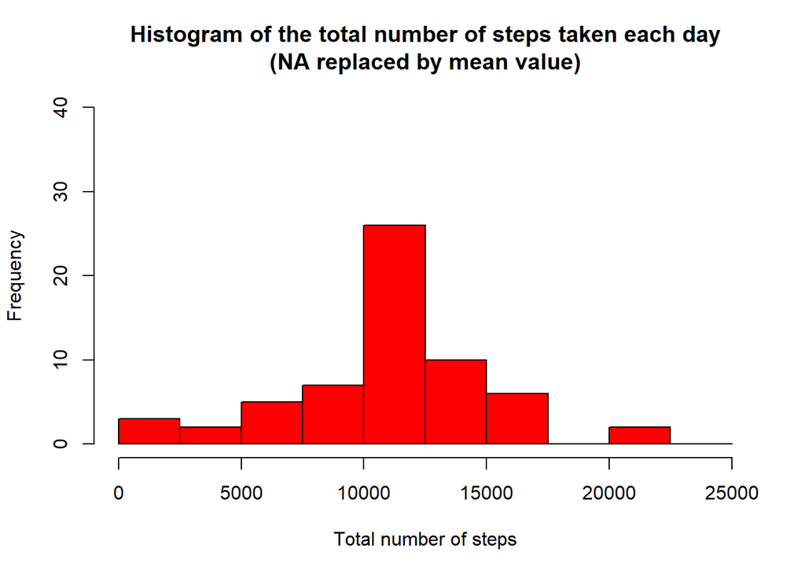

```r
hist(sum_data$total,
     breaks=seq(from=0, to=25000, by=2500),
     col="red",
     xlab="Total number of steps",
     ylim=c(0, 40),
     main="Histogram of the total number of steps taken each day\n(NA replaced by mean value)")
```

##Create a new factor variable in the dataset with two levels – “weekday” and “weekend” indicating whether a given date is a weekday or weekend day.

```r
DayType <- function(date) {
  day <- weekdays(date)
  if (day %in% c('Monday', 'Tuesday', 'Wednesday', 'Thursday', 'Friday'))
    return ("weekeday")
  else if (day %in% c('Saturday', 'Sunday'))
    return ("weekend")
  else
    stop ("Invalid Date Format.")
}
data$date <- as.Date(data$date)
data$day <- sapply(data$date, FUN = DayType)
```

##Make a panel plot containing a time series plot (i.e. type = “l”) of the 5-minute interval (x-axis) and the average number of steps taken, averaged across all weekday days or weekend days (y-axis).

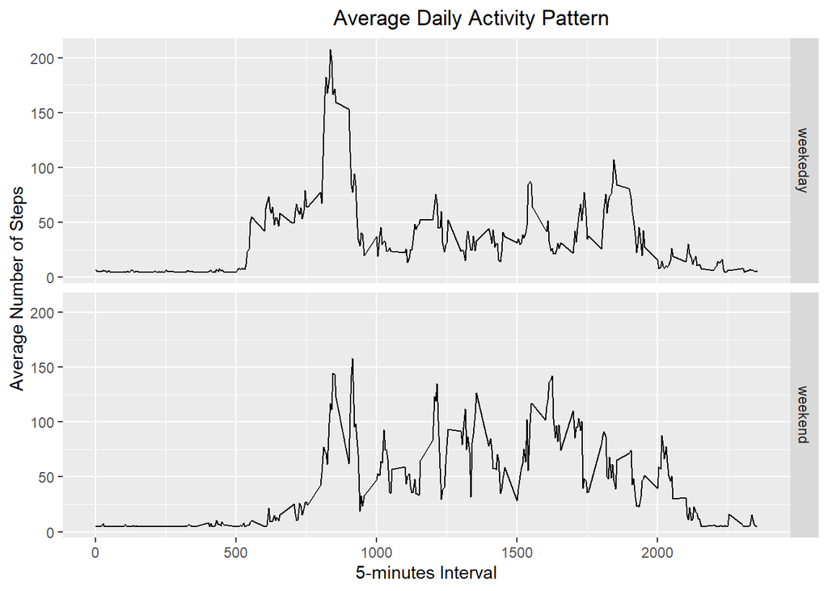

```r
library (ggplot2)
meanStepsByDay <- aggregate(steps ~ interval + day, data, mean)
ggplot(data = meanStepsByDay, aes(x = interval, y = steps)) +
  geom_line() +
  facet_grid(day ~ .) +
  ggtitle("Average Daily Activity Pattern") +
  xlab("5-minutes Interval") +
  ylab("Average Number of Steps") +
  theme(plot.title = element_text(hjust = 0.6))
```